# HW2

Benjamin Panny

2023-09-29

```r
egfr %>% count(site, surgery)
```

```
## # A tibble: 12 × 3
##     site surgery     n
##    <dbl>   <dbl> <int>
##  1     1       1   192
##  2     1       2    36
##  3     2       1   116
##  4     2       2     4
##  5     3       1   176
##  6     3       2    84
##  7     4       1   120
##  8     4       2    80
##  9     5       1   192
## 10     5       2    56
## 11     6       1    92
## 12     6       2    52
```

```r
egfr %>% count(subject)
```

```
## # A tibble: 300 × 2
##    subject     n
##      <dbl> <int>
##  1      23     4
##  2      25     4
##  3      28     4
##  4      30     4
##  5      33     4
##  6      41     4
##  7      45     4
##  8      50     4
##  9      57     4
## 10      67     4
## # ℹ 290 more rows
```

```r
egfr %>% count(time)
```

```
## # A tibble: 4 × 2
##    time     n
##   <dbl> <int>
## 1     0   300
## 2    12   300
## 3    24   300
## 4    36   300
```

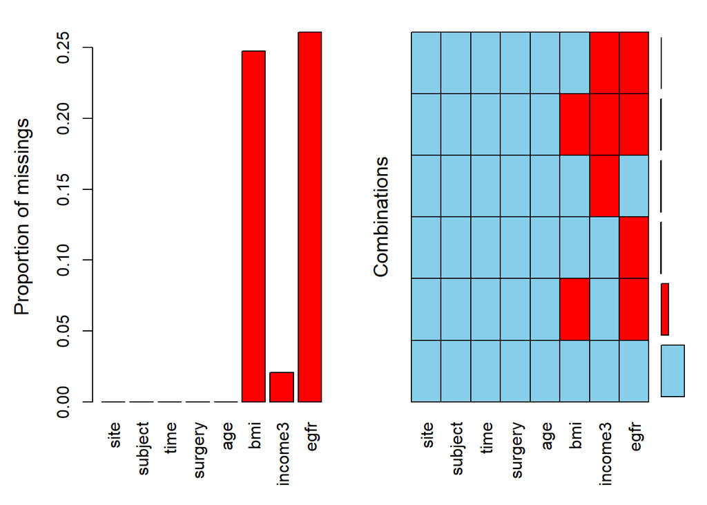

```r
aggr(egfr)
```

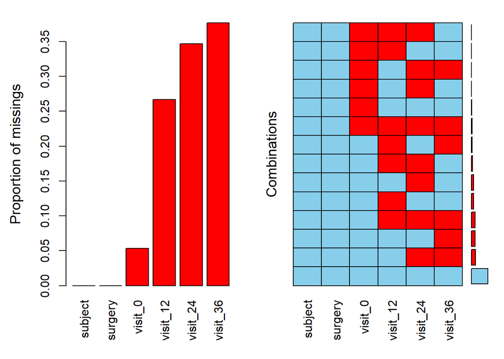

```r
egfr_wide <- egfr %>%
  select(subject, surgery, time, measure = egfr) %>%
  pivot_wider(names_from = "time",
              names_prefix = "visit_",
              values_from = "measure")
aggr(egfr_wide)
```

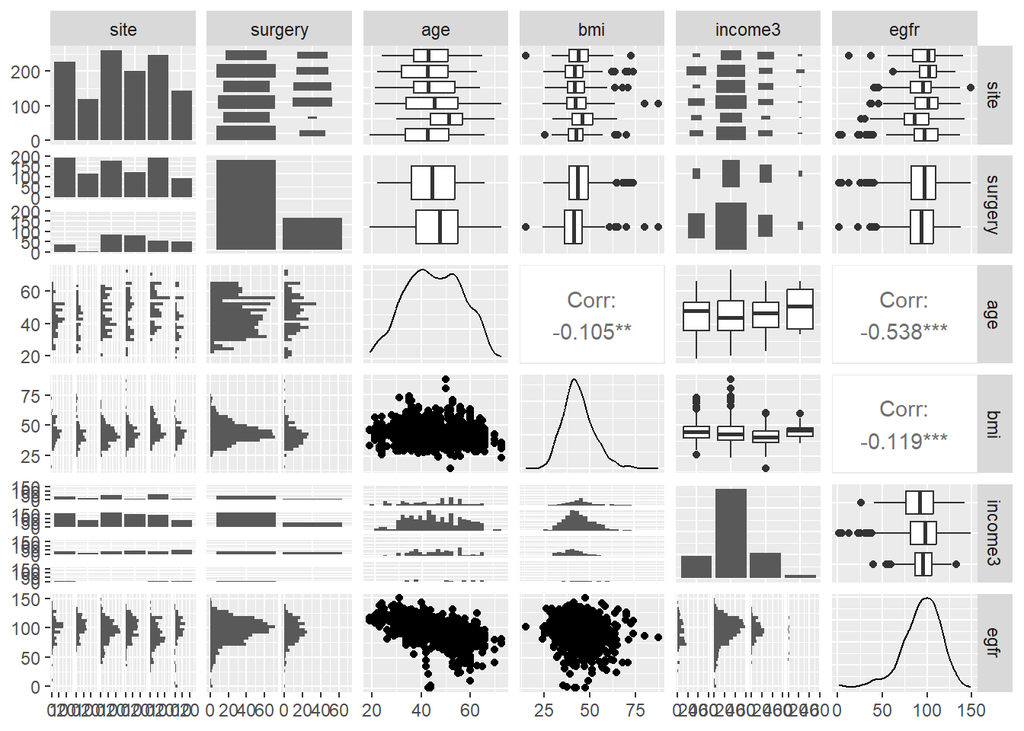

```r
egfr %>%
  mutate(income3 = factor(income3),
         surgery = factor(surgery),
         site = factor(site)) %>%
  GGally::ggpairs(columns = c(1, 4:8))
```

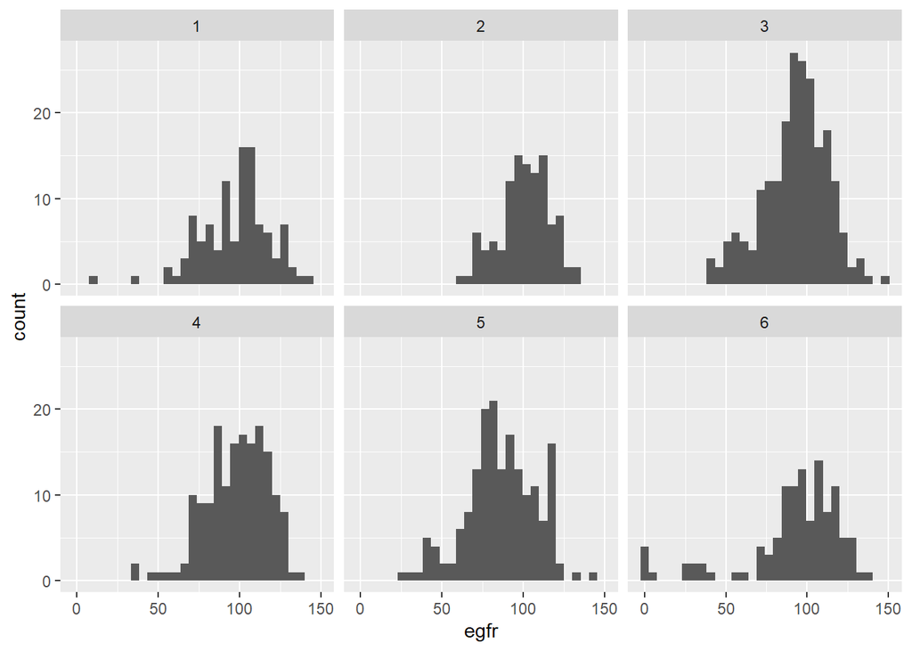

```r
egfr %>%
  ggplot(aes(x = egfr))+
  geom_histogram()+
  facet_wrap(~site)
```

Variable Description site Clinical site ID subject Subject ID surgery Bariatric Surgery Type 1 = “RYGB”, 2 = “LAGB” <- Roux-en-Y gastric bypass surgery and Laparoscopic adjustable gastric band surgery time Visit time in months 0 = Baseline, 12 = 12-Month, 24 = 24-Month, 36 = 36-Month age Participant’s age (years) at baseline income3 Household income at each visit 0= Less than 25,000, 1= 25,000-99,999, 2= 100,000 or greater egfr Estimated glomerular filtration rate (eGFR) at each visit (lower is worse, above 90 is OK)

Investigators are interested in evaluating whether one type of surgery resulted in greater improvement in eGFR than the other type of surgery, and whether eGFR values were consistently better over time for one type of surgery as compared to the other, assuming that the effects of adjusting covariates on eGFR were equal in different surgery types. Adjusting covariates include age and income level. Note that income level is a time-varying measurement.

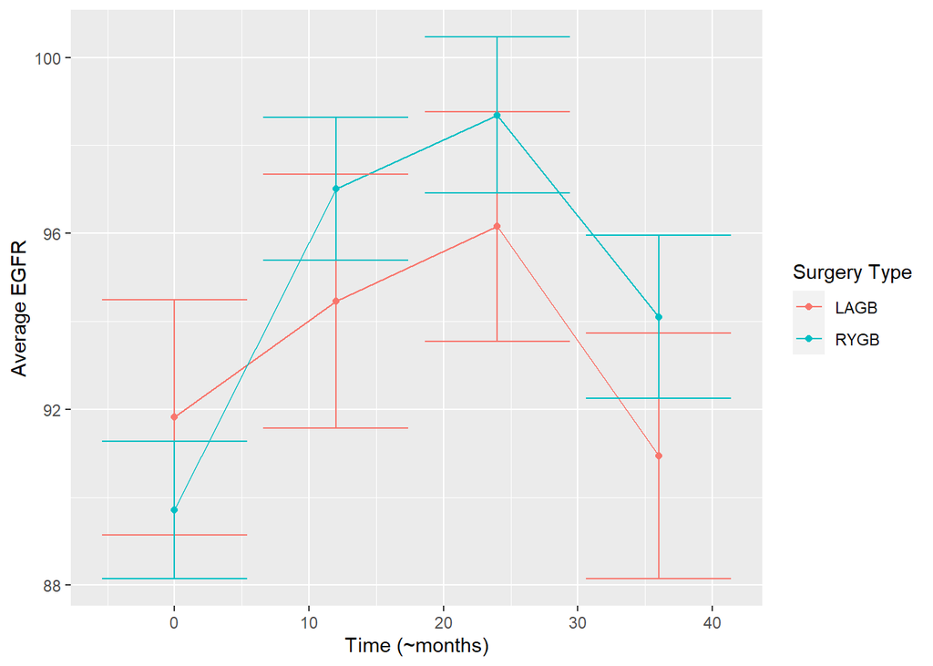

```r
egfr %>%
  mutate(surgery = if_else(surgery == 1, "RYGB", "LAGB")) %>%
  group_by(surgery, time) %>%
  summarise(avg = mean(egfr, na.rm = TRUE),
            stdev = sd(egfr, na.rm = TRUE) / sqrt(n() - sum(is.na(egfr)))) %>%
  ggplot(aes(x = time, y = avg, color = factor(surgery)))+
  geom_point()+
  geom_line()+
  geom_errorbar(aes(ymin = avg - stdev, ymax = avg + stdev)) +
  labs(color = "Surgery Type", x = "Time (~months)", y = "Average EGFR")
```

```r
missing_egfr <- egfr_wide %>%
  group_by(surgery) %>%
  summarise(na_time_0 = sum(is.na(visit_0)) / n(),
            na_time_12 = sum(is.na(visit_12)) / n(),
            na_time_24 = sum(is.na(visit_24)) / n(),
            na_time_36 = sum(is.na(visit_36)) / n()) %>%
  pivot_longer(cols = contains("na_time"),
               names_to = "time",
               values_to = "prop_missing") %>%
  mutate(time = as.numeric(substr(time, 9, 12))) %>%
  ungroup()

avg_egfr <- egfr %>%
  group_by(surgery, time) %>%
  summarise(avg = mean(egfr, na.rm = TRUE)) %>%
  ungroup()
```

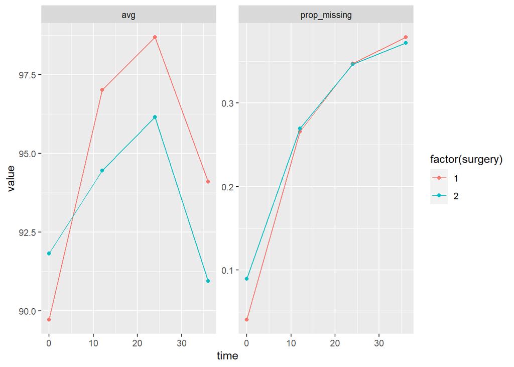

```r
avg_and_missing_egfr <- missing_egfr %>%
  left_join(avg_egfr, by = c("surgery", "time")) %>%
  pivot_longer(cols = c("avg", "prop_missing"),
               names_to = "value_type",
               values_to = "value")

avg_and_missing_egfr %>%
  ggplot(aes(x = time, y = value, color = factor(surgery)))+
  geom_point()+
  geom_line()+
  facet_wrap(~value_type, scales = "free_y")
```

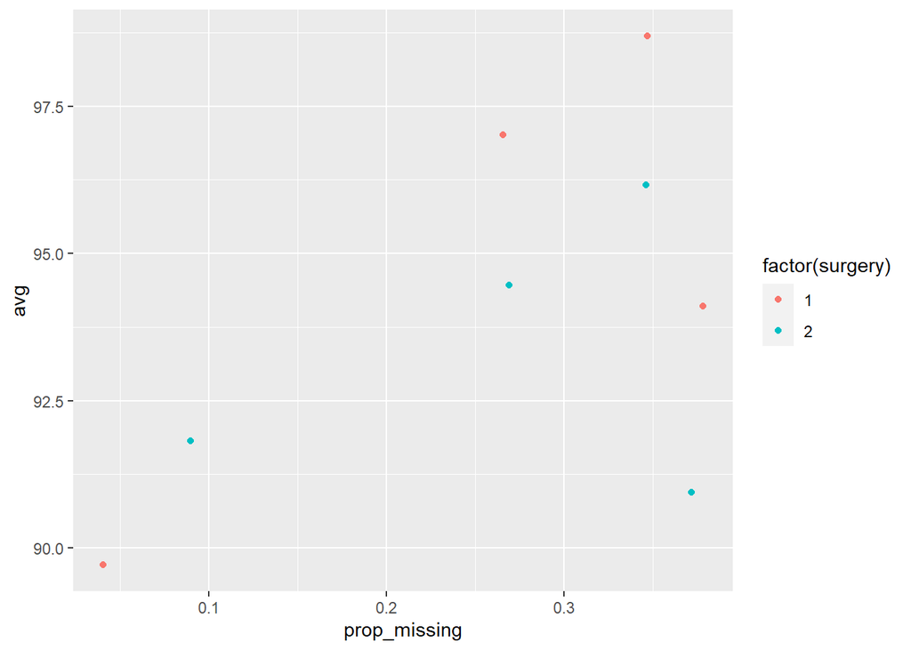

```r
missing_egfr %>%
  left_join(avg_egfr, by = c("surgery", "time")) %>%
  ggplot(aes(x = prop_missing, y = avg, color = factor(surgery)))+
  geom_point()
```

2. Describe a 3-level hierarchical clustering model that you choose to address the primary questions and the associated assumptions. Explicitly specify the fixed effects and the random effects, if any, and justify your choices. (25 pts)

The study aimed to investigate if the surgery improves kidney functioning and if the improvement differs between Roux-en-Y gastric bypass (RYGB) surgery and laparoscopic adjustable gastric band (LAGB) surgery. The study was also intended to identify factors associated with improvement in kidney functioning in the first 3 years after bariatric surgery.

The study is interested in whether or not surgery improves kidney function AND if the improvement differs between RYGB surgery and LAGB surgery. We should therefore estimate the average change within site and subjects given surgery. It was also intended to identify factors associated with improvement in the first 3 years.

Between-site heterogeneity can be modeled by a site-level random intercept Between-subject heterogeneity can be modeled by a subject-level random intercept

We are not interested in subject-specific or site-specific effects, so we will not include them as fixed effects.

Example: *If we are interested in estimating clinic effects, we will treat clinics as fixed effects. If we are interested in how treatment affect outcomes differently in different clinic, we will treat clinics as fixed effects.*

**Fixed or Random Effects**

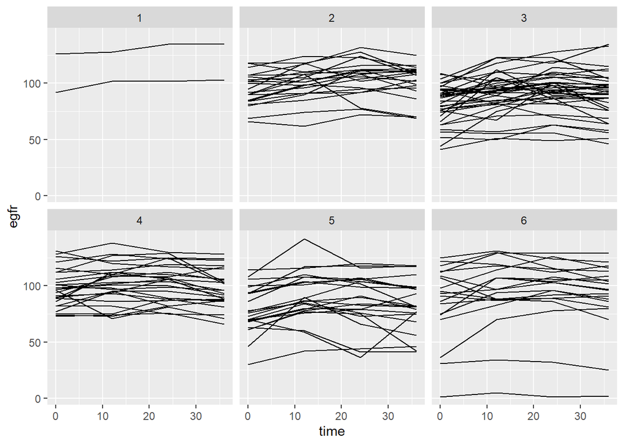

```r
spaghetti_egfr <- egfr %>%
  group_by(subject) %>%
  filter(!any(is.na(egfr))) %>%
  ungroup()

spaghetti_egfr <- egfr %>%
  semi_join(spaghetti_egfr, by = "subject")

spaghetti_egfr %>%
  ggplot(aes(x = time, y = egfr, group = subject)) +
  geom_line()+
  facet_wrap(~site)
```

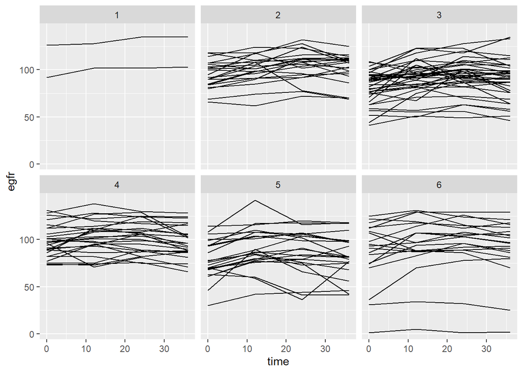

```r
spaghetti_egfr %>%
  ggplot(aes(x = time, y = egfr, group = subject)) +
  geom_line()+
  facet_wrap(~site)
```

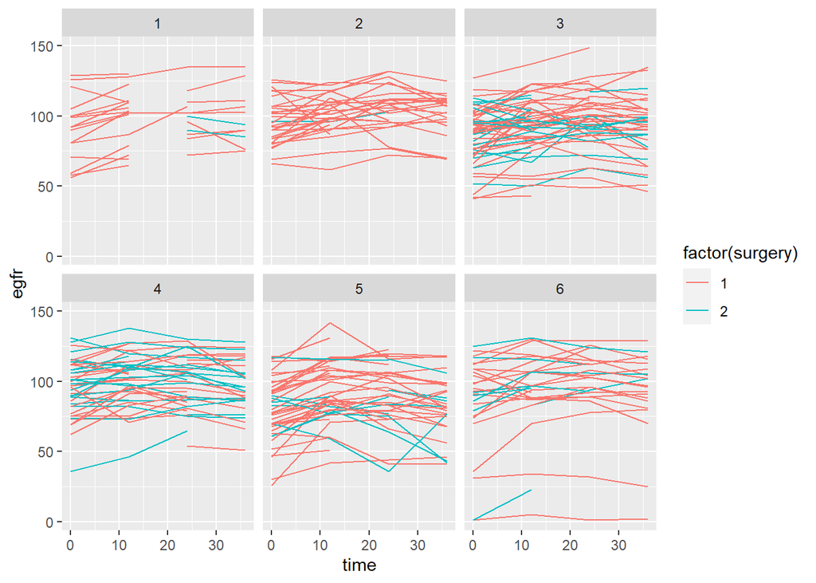

```r
egfr %>%
  ggplot(aes(x = time, y = egfr, group = subject, color = factor(surgery))) +
  geom_line()+
  facet_wrap(~site)
```

It is clear the effect of time varies within subjects and therefore within sites, but this effect appears as though it can be captured by adding a quadratic term given the inverted U shape of some of these lines.

We are interested in the effect of surgery, so it will be included as a fixed main coefficient We are also interested in whether or not EGFR is consistently better over time for one type of surgery compared to the other, so we will include a fixed interaction coefficient. It is also clear there is a quadratic pattern over time, so we will include a fixed quadratic time coefficient. The effect of surgery does not vary between occasions

There are repeated measurements within subjects and within sites. Therefore, this will be a three-level model.

- The overall mean EGFR, when `surgery == 1`
  - $\mathbb{E}\left[Y_{ijk}\right] = \beta_0$.
- The mean measurement for site `i`
  - $\mathbb{E}\left[Y_{ijk}\mid\zeta_i\right] = \beta_0 + \zeta_{0i}$
- The mean measuremnt for subject `j`
  - $\mathbb{E}\left[Y_{ijk}\mid\zeta_i, \zeta_{ij}\right] = \beta_0 + \zeta_{0i} + \zeta_{ij}$
- The overall average change in EGFR, given the effect of surgery, holding other covariates constant
  - $\mathbb{E}\left[Y_{ijk}\mid\ \beta_0, \zeta_{0i}, \zeta_{0ij},\beta_1,\text{surgery}_{ij}\right] = \beta_0 + \zeta_{0i} + \zeta_{0ij} + \beta_1\text{surgery}_{ij}$.
- The overall average change in EGFR, given the effect of surgery, holding other covariates constant, for site `i`
  - $\mathbb{E}\left[Y_{ijk}\mid\beta_0, \zeta_{0i}, \zeta_{0ij},\zeta_{1i},\text{surgery}_{ij}\right] = \beta_0 + \zeta_{0i} + \zeta_{0ij} + \beta_1\text{surgery}_{ij} + \zeta_{1i}\text{surgery}_{ij}$
- The overall average change in EGFR, given the effect of surgery, holding other covariates constant, for subject `j`
  - $\Delta{\mathbb{E}\left[Y_{ijk}\mid\beta_0, \zeta_{0i}, \zeta_{0ij},\zeta_{1i}, \zeta_{1ij}, \text{surgery}_{ij}\right]} = \beta_0 + \zeta_{0i} + \zeta_{0ij} + \beta_1\text{surgery}_{ij} + \zeta_{1i}\text{surgery}_{ij} + \zeta_{1ij}\text{surgery}_{ij}$
- The overall average EGFR, given the effect of time, holding other covariates constant
  - $\mathbb{E}\left[Y_{ijk}\mid\ \beta_0, \zeta_{0i}, \zeta_{0ij},\beta_2,\text{time}_{ijk}\right] = \beta_0 + \zeta_{0i} + \zeta_{0ij} + \beta_2\text{time}_{ijk}$.
- The overall average change in EGFR, given the effect of time, holding other covariates constant, for site `i`
  - $\mathbb{E}\left[Y_{ijk}\mid\beta_0, \zeta_{0i}, \zeta_{0ij},\beta_2,\zeta_{2i},\text{time}_{ij}\right] = \beta_0 + \zeta_{0i} + \zeta_{0ij} + \beta_2\text{time}_{ijk} + \zeta_{2i}\text{time}_{ijk}$
- The overall average change in EGFR, given the effect of time, holding other covariates constant, for site `i`
  - $\mathbb{E}\left[Y_{ijk}\mid\beta_0, \zeta_{0i}, \zeta_{0ij},\zeta_{2i}, \zeta_{2ij}, \text{time}_{ij}\right] = \beta_0 + \zeta_{0i} + \zeta_{0ij} + \beta_2\text{time}_{ijk} + \zeta_{2i}\text{time}_{ijk} + \zeta_{2ij}\text{time}_{ijk}$

$$\text{EGFR}_{ijk} = \beta_0 + \zeta_{0i} + \zeta_{0ij} +
\beta_1*\text{surgery}_{ij} + \beta_2*\text{time}_{ijk} +
\beta_3*\text{surgery}_{ij}*\text{time}_{ijk} +
\beta_4*\text{time}_{ijk}^{2}$$

Where:

- $\text{i} = \text{Site}$
- $\text{j} = \text{Subject}$
- $\text{k} = \text{Timepoint}$

Investigators are interested in evaluating whether one type of surgery resulted in greater improvement in eGFR than the other type of surgery, and whether eGFR values were consistently better over time for one type of surgery as compared to the other, assuming that the effects of adjusting covariates on eGFR were equal in different surgery types. Adjusting covariates include age and income level. Note that income level is a time-varying measurement.

```r
egfr_for_lmer <- egfr %>%
  mutate(income3 = factor(income3),
         site = factor(site),
         subject = factor(subject),
         surgery = factor(surgery))
lmer_1 <- egfr_for_lmer %>% lmer(egfr ~ surgery*time + I(time^2) + (1 | subject/site),
                                 data = .,
                                 REML = F)
lmer_1 %>% summary()
```

```
## Linear mixed model fit by maximum likelihood . t-tests use Satterthwaite's
##   method [lmerModLmerTest]
## Formula: egfr ~ surgery * time + I(time^2) + (1 | subject/site)
##    Data: .
##
##      AIC      BIC   logLik deviance df.resid
##   7088.7   7127.0  -3536.3   7072.7      879
##
## Scaled residuals:
##     Min      1Q  Median      3Q     Max
## -3.5892 -0.4737  0.0253  0.4857  2.8279
##
## Random effects:
##  Groups       Name        Variance Std.Dev.
##  site:subject (Intercept) 300.7    17.341
##  subject      (Intercept) 123.2    11.100
##  Residual                  63.7     7.981
## Number of obs: 887, groups:  site:subject, 292; subject, 292
##
## Fixed effects:
##                 Estimate Std. Error         df t value Pr(>|t|)
## (Intercept)    89.938485   1.490680 334.332997  60.334  < 2e-16 ***
## surgery2        1.125839   2.933310 322.227636   0.384 0.701371
## time            0.894935   0.072197 601.581933  12.396  < 2e-16 ***
## I(time^2)      -0.019887   0.001957 599.150426 -10.163  < 2e-16 ***
## surgery2:time  -0.168295   0.047712 602.244439  -3.527 0.000452 ***
## ---
## Signif. codes:  0 '***' 0.001 '**' 0.01 '*' 0.05 '.' 0.1 ' ' 1
##
## Correlation of Fixed Effects:
##             (Intr) srgry2 time   I(t^2)
## surgery2    -0.498
## time        -0.207  0.035
## I(time^2)    0.136  0.005 -0.941
## surgery2:tm  0.118 -0.239 -0.172 -0.002
```

```r
lmer_1_re <- egfr_for_lmer %>% lmer(egfr ~ surgery*time + I(time^2) + (1 | subject/site),
                                 data = .,
                                 REML = T)
lm_1 <- egfr_for_lmer %>% lm(egfr ~ surgery*time + I(time^2),
                                 data = .)
```